# Linear Time Series Models for Financial Data

Mark Preston

February 1, 2019

## ARMA Modelling with CRSP Portfolio and Moody’s AAA Bonds

This week, I’ll be using linear time series models to evaluate portfolio and bond returns. Additionally, I’ll also forecast returns for the second decile of the CRSP portfolio. As a starting point, I’ve loaded both data sets. For both, I’ve added columns for log returns.

```r
library(tidyverse)
library(forecast)
library(TSA)
library(tseries)
library(fracdiff)
library(lmtest)
library(kableExtra)
library(knitr)

#setting prefered ggplot theme
theme_set(
  theme_minimal()
)

colours <- c("dodgerblue2", "darkorange", "darkorchid3", "forestgreen")

#custom table function used throughout analysis
custom_kable <- function(x){
  kable(x, format = "html") %>%
    kable_styling(bootstrap_options = "striped")
}

crsp_returns <- read.table("m-dec125910-6111.txt", sep = "", header = T)

crsp_dec2 <- crsp_returns %>%
  select(dec2) %>%
  mutate(log_return = log(dec2 + 1),
         record = row_number()) %>%
  select(record, dec2, log_return)

bond_yields <- read.table("m-aaa.txt", sep = "", header = T) %>%
  unite(c("year", "mon", "day"), col = "date", sep = "/", remove = T) %>%
  mutate(date = as.Date(date),
         log_yield = log(yield)) %>%
  slice(-1)
```

### Modelling Second Decile from CRSP portfolios

I’ve started here by constructing a summary statistics table for both log and normal returns. Both show that the second decile of monthly CRSP returns are, on average, positive.

```r
yield_summary <- function(data){
data %>%
  select(-1) %>%
  gather(key = "return_type", value = "return_value") %>%
  group_by(return_type) %>%
  summarise(return_min = min(return_value),
            return_median = median(return_value),
            return_mean = mean(return_value),
            return_max = max(return_value))
}

yield_summary(data = crsp_dec2) %>%
  custom_kable()
```

| return_type | return_min | return_median | return_mean | return_max |
| --- | --- | --- | --- | --- |
| dec2 | -0.2267650 | 0.0131810 | 0.0092843 | 0.1767480 |
| log_return | -0.2571723 | 0.0130949 | 0.0081131 | 0.1627547 |

This is further confirmed when reviewing the density plot for each return column. Overall, it appears this portfolio was a good holding since it generally showed positive returns. While these do not account for any risk adjustments, the CRSP monthly returns here look promising. Since the portfolio is based on the market capitalization of NYSE/AMEX/NASDAQ, this result seems intuitive.

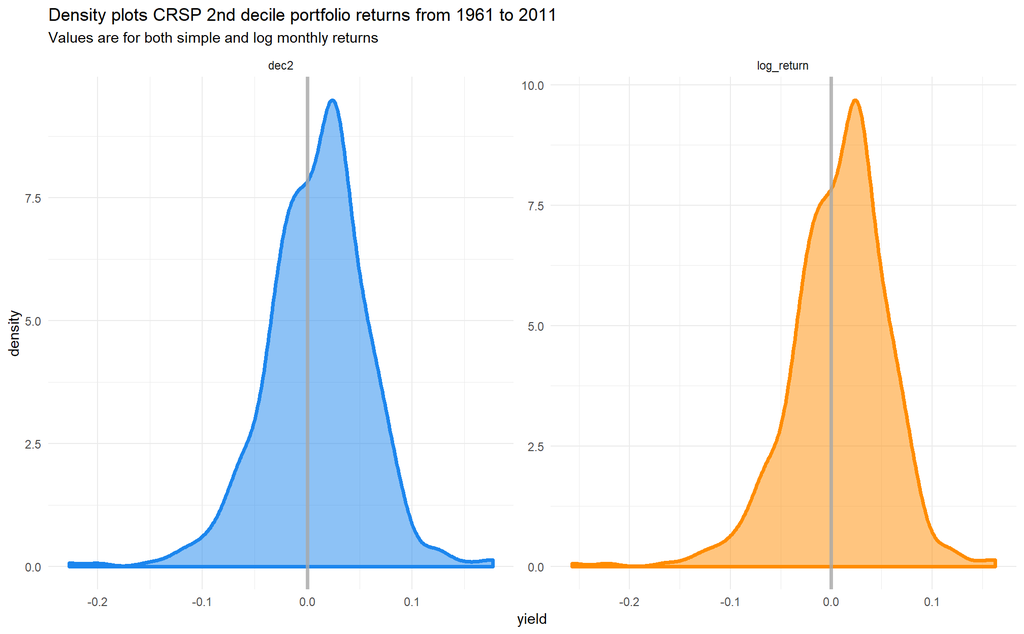

```r
crsp_dec2 %>%
  select(-record) %>%
  gather(key = "yield_type", value = "yield") %>%
  ggplot(aes(yield, colour = yield_type, fill = yield_type)) +
  geom_density(size = 1.3, show.legend = F, alpha = .5) +
  geom_vline(xintercept = 0, size = 1.3, colour = "darkgray", alpha = .8) +
  facet_wrap(facets = "yield_type", scales = "free") +
  scale_colour_manual(values = colours) +
  scale_fill_manual(values = colours) +
  labs(title = "Density plots CRSP 2nd decile portfolio returns from 1961 to 2011",
       subtitle = "Values are for both simple and log monthly returns")
```

The time series plot for both columns show the variability of each return. The biggest negative spikes occur in the 1987 and 2008 stock market crashes while the positive spikes take place in 1975, possibly post-Breton Woods dissolution, and 2009 post-recession.

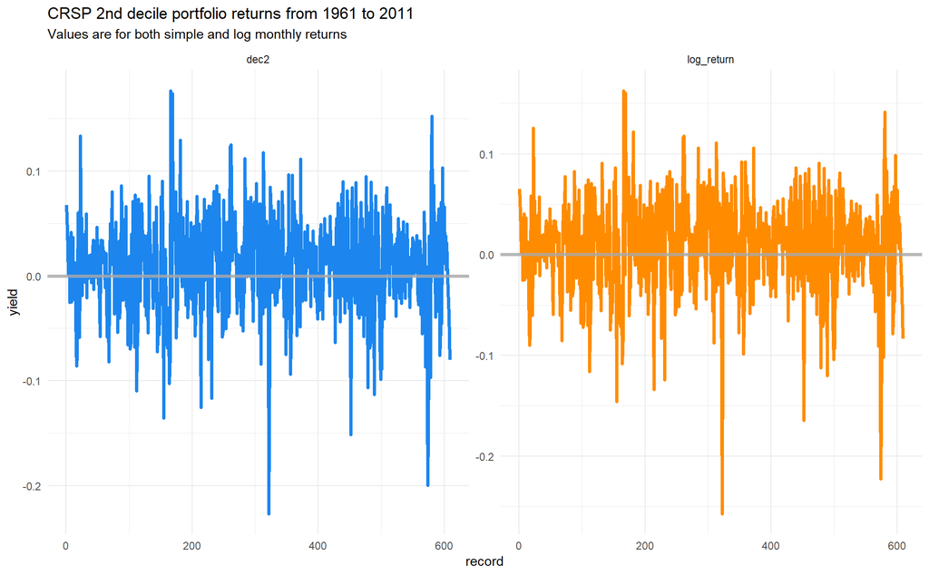

```r
crsp_dec2 %>%
  gather(key = "yield_type", value = "yield", -record) %>%
  ggplot(aes(record, yield, colour = yield_type)) +
  geom_line(size = 1.3, show.legend = F) +
  geom_hline(yintercept = 0, size = 1.3, colour = "darkgray", alpha = .8) +
  facet_wrap(facets = "yield_type", scales = "free") +
  scale_colour_manual(values = colours) +
  labs(title = "CRSP 2nd decile portfolio returns from 1961 to 2011",
       subtitle = "Values are for both simple and log monthly returns")
```